# **orchaRd 2.0: An R package for drawing ‘orchard’ plots (and ‘caterpillars’ plots) from meta-analyses and meta-regressions**

- Show All Code
- Hide All Code
- View Source

Author

**S. Nakagawa, M. Lagisz, R. E. O’Dea, P. Pottier, J. Rutkowska, Y. Yang, A. M. Senior & D.W.A. Noble**

Published

August 29, 2026

# 1 **Introduction**

[figure not shown]

`orchaRd` 2.0 allows users to create pretty orchard plots that contain both confidence intervals (CIs) and prediction intervals (PIs) around point estimates for different categorical moderators, plots the effect size distribution over top such estimates and weights effect sizes by their precision (1/standard error, SE) or sample size. `orchaRd` takes a `metafor` object of class `rma.mv` or `rma` (Viechtbauer 2010) and plots the results for the meta-analytic or meta-regression model.

`orchaRd` 2.0 now allows users to take meta-regression models with a multitude of moderator variables that are categorical or continuous along with heterogeneous residual variance models. This is achieved by allowing the user to produce marginalised mean estimates using the `emmeans` package. For plotting, `orchaRd` uses `ggplot2` (Wickham 2009), and as such, layers can be added directly to make plots customizable to the users needs. Also, the function `orchard_plot` uses the principles of bee swarm plots to visualise individual effect sizes (Eklund 2012; see also Clarke and Sherrill-Mix 2017; Sherrill-Mix and Clarke 2017).

In addition to orchard plots, we have another plotting function `caterpillars` to draw caterpillar(s) plots. Furthermore, the package `orchaRd` comes with two functions that are useful for multilevel meta-analysis and meta-regression (i.e., `rma.mv`): 1) `i2_ml` to calculate the ‘total’ I<sup>2</sup> along with I<sup>2</sup> for each level (*sensu* Nakagawa S and Santos 2012; see also A. M. Senior et al. 2016) and 2) `r2_ml` to calculate marginal and conditional R<sup>2</sup> for mixed models (*sensu* S. Nakagawa and Schielzeth 2013).

# 2 **Citing orchaRd**

To cite `orchaRd` 2.0 in publications one can use the following reference:

Shinichi Nakagawa, Malgorzata Lagisz, Rose E. O’Dea, Patrice Pottier, Joanna Rutkowska, Alistair M. Senior, Yefeng Yang, Daniel W.A. Noble. 2023. orchaRd 2.0: An R package for visualizing meta-analyses with orchard plots. **Methods in Ecology and Evolution**, https://doi.org/10.1111/2041-210X.14152 (preprint = **EcoEvoRxiv**, https://doi.org/10.32942/X2QC7).

For earlier versions please cite:

Nakagawa, S., Lagisz, M., O’Dea, R. E., Rutkowska, J., Yang, Y., Noble, D. W., & Senior, A. M. (2021). The Orchard Plot: Cultivating Forest Plots for Use in Ecology, Evolution and Beyond. **Research Synthesis Methods**, 12: 4-12, https://doi.org/10.1002/jrsm.1424 (preprint = *EcoEvoRxiv* https://doi.org/10.32942/osf.io/epqa7)

# 3 **Installation**

`orchaRd` is on CRAN, so most users should install the released version with the code below.

**Note**

If you want the development version, which may contain newer features not yet on CRAN, you can install it from GitHub instead:

```r
# install.packages("remotes")
remotes::install_github("daniel1noble/orchaRd", ref = "dev")
pacman::p_load(tidyverse, metafor, patchwork, R.rsp, orchaRd, emmeans, ape, phytools, flextable, rotl, clubSandwich, glmmTMB, lme4)
```

It’s important to note that this version may not be as stable as the CRAN release.

```r
# Install the released version of orchaRd from CRAN
install.packages("orchaRd")

# Load orchaRd together with the other packages used throughout this vignette
# install.packages("pacman")
pacman::p_load(orchaRd, tidyverse, metafor, patchwork, R.rsp, emmeans, ape, phytools, flextable, glmmTMB, lme4)
```

Installing `orchaRd` from CRAN will make the primary functions accessible to users along with their help files, and will automatically install its required dependencies (including `metafor`). The examples in this vignette also make use of the `tidyverse` and `metafor` packages.

# 4 **Examples of orchard and caterpillars plots**

In this vignette we’ll walk the reader through a number of case studies and show you how you can create beautiful looking orchard plots. We overview three different case studies that make use of different effect sizes and moderators. The data sets associated with each case study come as part of the `orchaRd` package.

## 4.1 **Example 1: Dietary Restriction and Lifespan**

English and Uller (2016) performed a systematic review and meta-analysis on the effects of early life dietary restriction (a reduction in a major component of the diet without malnutrition; e.g. caloric restriction) on average age at death, using the standardised mean difference (often called *d*). They found that, across the whole data set, there was little evidence for an effect of dietary restriction on mean age at death. Here we’ll use the data set to first calculate the effect size measures and then fit an intercept only, meta-analytic model.

```r
data(english)

# We need to calculate the effect sizes, in this case d
english <- escalc(measure = "SMD", n1i = NStartControl, sd1i = SD_C, m1i = MeanC, n2i = NStartExpt, sd2i = SD_E, m2i = MeanE,
                  var.names=c("SMD","vSMD"),
                  data = english)

english_MA <- rma.mv(yi = SMD, V = vSMD, random = list( ~ 1 | StudyNo, ~ 1 | EffectID), data = english)
summary(english_MA)
```

```
Multivariate Meta-Analysis Model (k = 77; method: REML)

  logLik  Deviance       AIC       BIC      AICc
-44.5943   89.1887   95.1887  102.1809   95.5220

Variance Components:

            estim    sqrt  nlvls  fixed    factor
sigma^2.1  0.0614  0.2478     21     no   StudyNo
sigma^2.2  0.0760  0.2756     77     no  EffectID

Test for Heterogeneity:
Q(df = 76) = 297.4722, p-val < .0001

Model Results:

estimate      se    zval    pval    ci.lb   ci.ub
  0.0572  0.0729  0.7845  0.4327  -0.0856  0.2000

---
Signif. codes:  0 '***' 0.001 '**' 0.01 '*' 0.05 '.' 0.1 ' ' 1
```

We have fit a meta-analytic model and thus the only estimate we see is the overall effect size on the effects of caloric restriction on mean death across all studies examined. Now that we have fit our meta-analytic model we can get the confidence intervals and prediction intervals with a few functions in the `orchaRd` package. If one is interested in getting the table of results we can use the `mod_results` function. This will allow users to make nice tables of the results if needed. We can do that as follows:

**Important**

In `orchaRd` version 2.1 and above, the data argument has now been removed from the `mod_results` and `orchard_plot`, `bubble_plot` and `catepillars` functions. This is because the data is already contained within the `metafor` object.

```r
model_results <- orchaRd::mod_results(english_MA, mod = "1", at = NULL,  group = "StudyNo")
model_results
```

```
     name estimate lowerCL upperCL lowerPR upperPR
1 Intrcpt    0.057  -0.086     0.2   -0.68     0.8
```

If we instead want to create an orchard plot and visualise the results we can do so quite simply as:

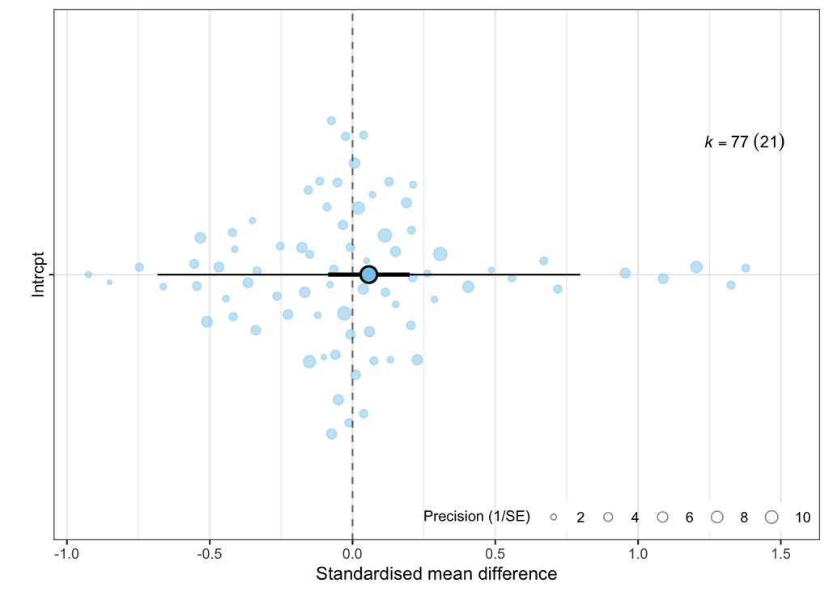

Figure 1— Orchard plot of the impact caloric restriction using standardised mean difference

```r
orchaRd::orchard_plot(english_MA, mod="1", group = "StudyNo", xlab = "Standardised mean difference", transfm = "none", twig.size = 0.5, trunk.size = 1)
```

In Fig. 1, we simply add in the metafor model and it will create a default orchard plot. Alternatively, we could also add in the table of results. Also. some people may wish to present the heterogeneity index, I<sup>2</sup> and, at the same time, change the colours of the ‘trunk and fruit’ by adding a few arguments.

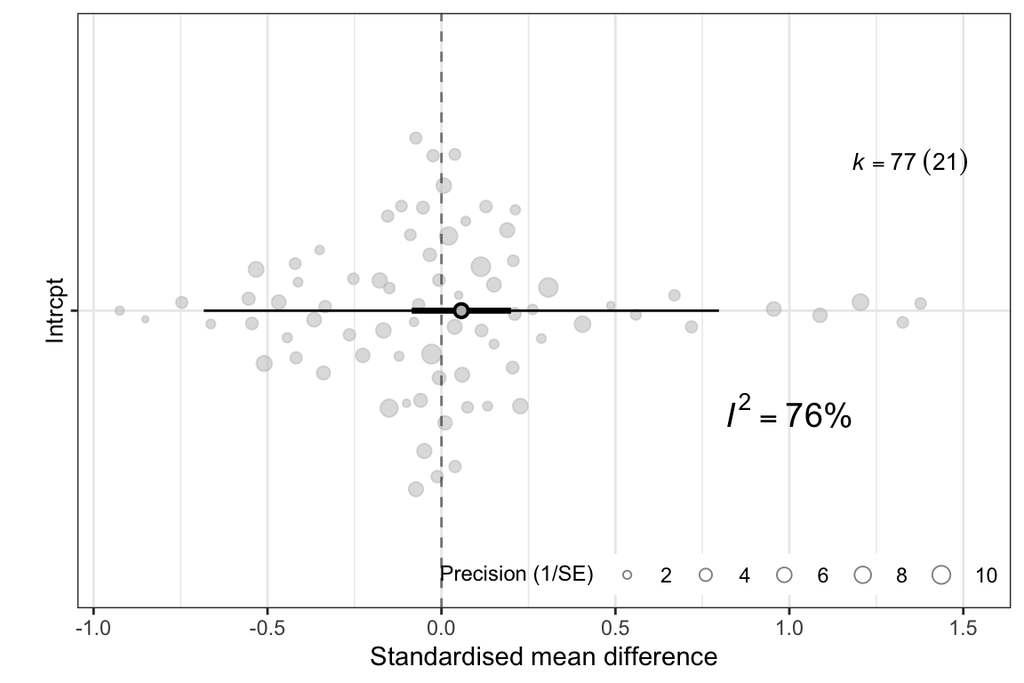

Figure 2— Orchard plot of the impact caloric restriction using standardised mean difference but instead of using the metafor model, using the model results table

```r
# use i2_sn function to obtain the total I^2

I2 <- orchaRd::i2_ml(english_MA)

orchaRd::orchard_plot(model_results, mod="1", xlab = "Standardised mean difference") +
  annotate(geom="text", x= 0.80, y= 1, label= paste0("italic(I)^{2} == ", round(I2[1],4), "*\"%\""),
              color="black", parse = TRUE, size = 5) +
  scale_fill_manual(values="grey") +
  scale_colour_manual(values="grey")
```

Figure Fig. 2 and Fig. 1 above show that overall estimate from a random-effects meta-analysis of 77 effect sizes is centered on zero, with a 95% CI that spans the line of no-effect. The prediction intervals clearly demonstrate the high level of heterogeneity (over 75%), with effects size less than -0.5 and greater than 0.5 predicted to be observed.

We can now draw a comparable caterpillar plot by using the function `caterpillars`.

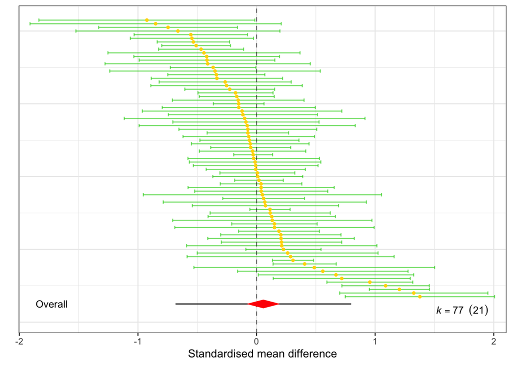

Figure 3— Catterpilar plot of the impact caloric restriction using standardised mean difference

```r
# a caterpillar plot (not a caterpillars plot)
orchaRd::caterpillars(model_results, mod="1", xlab = "Standardised mean difference")
```

It is now interesting to compare how the same data set can be visualised different by look at Fig. 2 and Fig. 3. It is good that the caterpillar plot can show CIs for each effect size. An equivalent function was done with the size of fruit in the orchard plot.

In a subsequent publication, Alistair M. Senior et al. (2017) analysed this data set for effects of dietary-restriction on among-individual variation in the age at death using the log coefficient of variation ratio. A major prediction in both English and Uller (2016) and Alistair M. Senior et al. (2017) was that the type of manipulation, whether the study manipulated quality of food versus the quantity of food would be important. As such, we can fit a meta-regression model to test whether the moderator “Manipulation Type” `ManipType` impacts our results on the mean and variance

```r
# First we need to calculate the lnCVR
english <- escalc(measure = "CVR", n1i = NStartControl, sd1i = SD_C, m1i = MeanC,
                        n2i = NStartExpt, sd2i = SD_E, m2i = MeanE,
                        var.names=c("lnCVR","vlnCVR"),
                        data = english)

# Now we can fit the meta-regression model (contrast)
english_MR0 <- rma.mv(yi = SMD, V = vSMD, mods = ~ ManipType,
                     random = list(~ 1 | StudyNo, ~ 1 | EffectID), data = english)
summary(english_MR0)
```

```
Multivariate Meta-Analysis Model (k = 77; method: REML)

  logLik  Deviance       AIC       BIC      AICc
-44.2108   88.4216   96.4216  105.6916   96.9931

Variance Components:

            estim    sqrt  nlvls  fixed    factor
sigma^2.1  0.0655  0.2560     21     no   StudyNo
sigma^2.2  0.0761  0.2758     77     no  EffectID

Test for Residual Heterogeneity:
QE(df = 75) = 295.5324, p-val < .0001

Test of Moderators (coefficient 2):
QM(df = 1) = 0.0414, p-val = 0.8388

Model Results:

                   estimate      se    zval    pval    ci.lb   ci.ub
intrcpt              0.0469  0.0924  0.5079  0.6115  -0.1342  0.2281
ManipTypeQuantity    0.0283  0.1390  0.2035  0.8388  -0.2442  0.3008

---
Signif. codes:  0 '***' 0.001 '**' 0.01 '*' 0.05 '.' 0.1 ' ' 1
```

```r
# Again, we can create a table of results
res2 <- orchaRd::mod_results(english_MR0, mod = "ManipType", group = "StudyNo")
res2
```

```
      name estimate lowerCL upperCL lowerPR upperPR
1  Quality    0.047   -0.13    0.23   -0.71    0.81
2 Quantity    0.075   -0.14    0.30   -0.69    0.84
```

```r
# we fit a meta-regression (contrast) for the log coefficient of variation
senior_MR0 <- rma.mv(
  yi = lnCVR, V = vlnCVR, mods = ~ ManipType, random = list(~ 1 | StudyNo, ~ 1 | EffectID),
  data = english
)
summary(senior_MR0)
```

```
Multivariate Meta-Analysis Model (k = 77; method: REML)

  logLik  Deviance       AIC       BIC      AICc
-31.5488   63.0976   71.0976   80.3676   71.6691

Variance Components:

            estim    sqrt  nlvls  fixed    factor
sigma^2.1  0.0271  0.1647     21     no   StudyNo
sigma^2.2  0.0460  0.2144     77     no  EffectID

Test for Residual Heterogeneity:
QE(df = 75) = 213.5803, p-val < .0001

Test of Moderators (coefficient 2):
QM(df = 1) = 1.2938, p-val = 0.2554

Model Results:

                   estimate      se     zval    pval    ci.lb   ci.ub
intrcpt             -0.1287  0.0674  -1.9101  0.0561  -0.2608  0.0034  .
ManipTypeQuantity    0.1192  0.1048   1.1374  0.2554  -0.0862  0.3247

---
Signif. codes:  0 '***' 0.001 '**' 0.01 '*' 0.05 '.' 0.1 ' ' 1
```

```r
# creating a table of results
res3 <- orchaRd::mod_results(senior_MR0, mod = "ManipType",  group = "StudyNo", at = list(ManipType = "Quality"), subset = TRUE)
res3
```

```
     name estimate lowerCL upperCL lowerPR upperPR
1 Quality    -0.13   -0.26  0.0034   -0.67    0.42
```

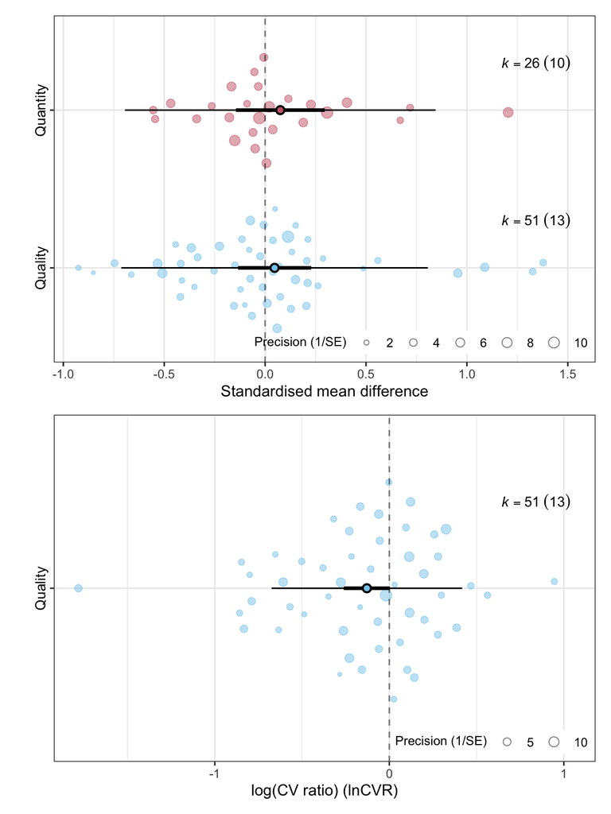

Figure 4— Orchard plot of diet qualities impact on SMD (top) and log coefficient of variation (bottom)

```r
# We can now plot SMD and lnCVR beside each other and compare the results
p1 <- orchaRd::orchard_plot(res2,
                   mod = "ManipType", group = "StudyNo", xlab = "Standardised mean difference")

p2 <- orchaRd::orchard_plot(res3,
  mod = "ManipType", group = "StudyNo", xlab = "log(CV ratio) (lnCVR)")

(p1 / p2)
```

Let’s draw comparable caterpillars plots to compare these two results again.

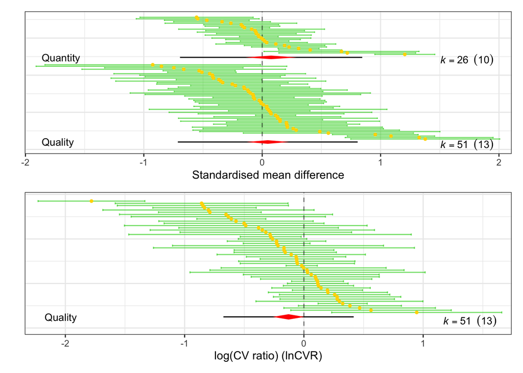

```r
# We can now plot SMD and lnCVR beside each other and compare the results
p1c <- orchaRd::caterpillars(res2,
                   mod = "ManipType", group = "StudyNo",  xlab = "Standardised mean difference")

p2c <- orchaRd::caterpillars(res3,
  mod = "ManipType",  group = "StudyNo", xlab = "log(CV ratio) (lnCVR)")

p1c / p2c
```

Now compare between Fig. 4 and Fig. 5. We think they both look nice.

## 4.2 **Example 2: Predation and Invertebrate Community**

Eklof et al. (2012) evaluated the effects of predation on benthic invertebrate communities. Using the log response ratio they quantified differences in abundance and/or biomass of gastropods and Amphipods in groups with and without predation in an experimental setting.

Here again, we can create orchard plots of the model results, but we’ll show how a few simple things can be modified. Again, we can fit the meta-analytic model first:

```r
data(eklof)

# Calculate the effect size
eklof <- escalc(
  measure = "ROM", n1i = N_control, sd1i = SD_control, m1i = mean_control,
  n2i = N_treatment, sd2i = SD_treatment, m2i = mean_treatment,
  var.names = c("lnRR", "vlnRR"),
  data = eklof
)

# Add the observation level factor
eklof$Datapoint <- as.factor(seq(1, dim(eklof)[1], 1))

# Also, we can get the sample size, which we can use for weighting if we would like
eklof$N <- rowSums(eklof[, c("N_control", "N_treatment")])

# fit a meta-regression with the intercept (contrast)
eklof_MR0 <- rma.mv(
  yi = lnRR, V = vlnRR, mods = ~ Grazer.type, random = list(~ 1 | ExptID, ~ 1 | Datapoint),
  data = eklof
)

summary(eklof_MR0)
```

```
Multivariate Meta-Analysis Model (k = 34; method: REML)

  logLik  Deviance       AIC       BIC      AICc
-50.7676  101.5353  109.5353  115.3982  111.0167

Variance Components:

            estim    sqrt  nlvls  fixed     factor
sigma^2.1  0.4707  0.6861     18     no     ExptID
sigma^2.2  0.6330  0.7956     34     no  Datapoint

Test for Residual Heterogeneity:
QE(df = 32) = 186.9384, p-val < .0001

Test of Moderators (coefficient 2):
QM(df = 1) = 0.9428, p-val = 0.3316

Model Results:

                      estimate      se     zval    pval    ci.lb    ci.ub
intrcpt                -0.7692  0.3024  -2.5439  0.0110  -1.3618  -0.1766  *
Grazer.typegastropod    0.3314  0.3413   0.9710  0.3316  -0.3376   1.0004

---
Signif. codes:  0 '***' 0.001 '**' 0.01 '*' 0.05 '.' 0.1 ' ' 1
```

Above we have fit a meta-regression model using “Grazer Type” as a moderator which is predicted to explain variation in log response ratios. We can demonstrate a few simple changes users can make, but we note here that users can make far more complex changes down the line if needed, but we’ll save explaining these more complex changes for the last example. The first is the angle at which the y-axis labels are positioned (bottom of Fig. 6):

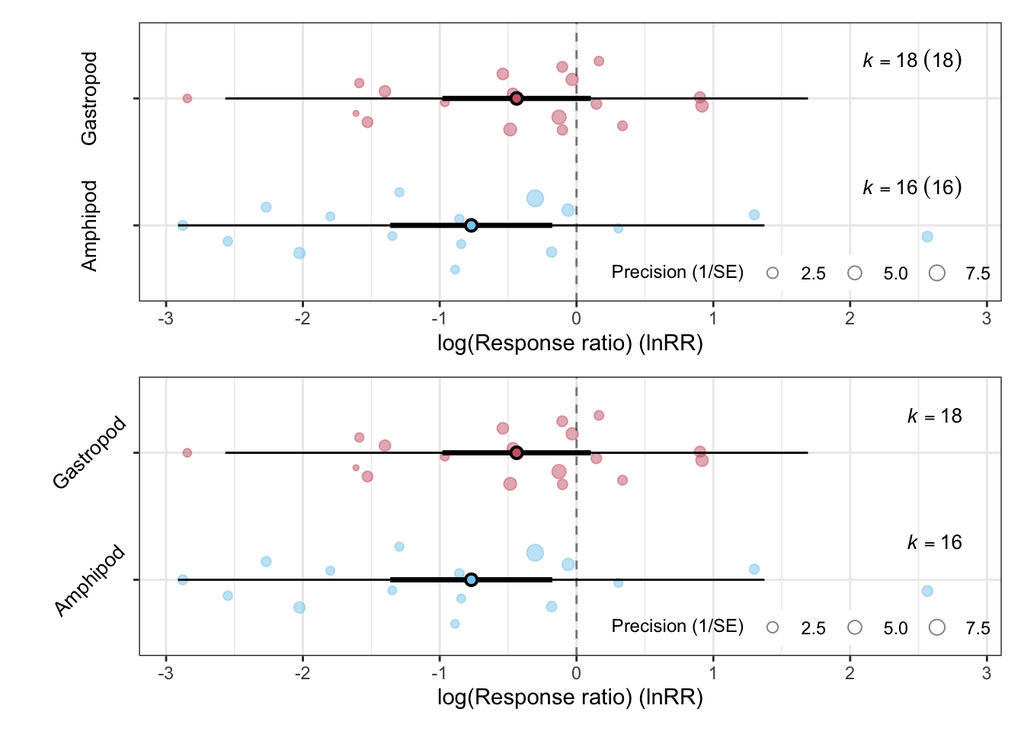

Figure 6— Orchard plots of the effects of predation on benthic invertebrate communities compared using the log response ratio. Top panel is the default plot and bottom panel a plot containing changes in label axes

```r
#|
f <- orchaRd::mod_results(eklof_MR0, mod = "Grazer.type",  group = "ExptID")

p3 <- orchaRd::orchard_plot(eklof_MR0, mod = "Grazer.type",  group = "ExptID", xlab = "log(Response ratio) (lnRR)",
  transfm = "none")

p4 <- orchaRd::orchard_plot(eklof_MR0, mod = "Grazer.type",  group = "ExptID", xlab = "log(Response ratio) (lnRR)",
  transfm = "none", angle = 45, g = FALSE)

p3/p4
```

The other thing we can change is the type of scaling we wish to use. Let’s say we are interested in scaling the effect size by the total sample size of the study we use a vector of N, sample size (bottom of Fig. 7:

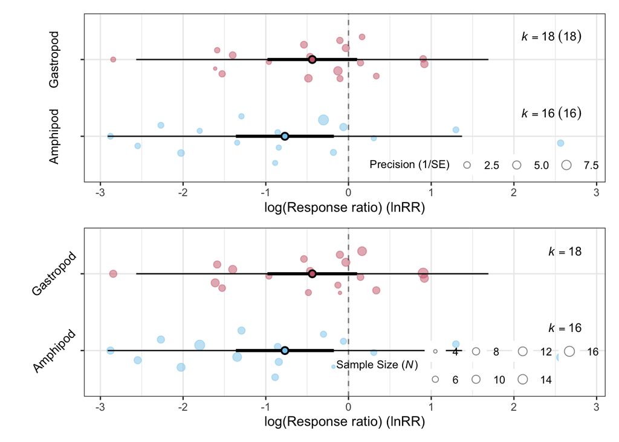

Figure 7— Orchard plots of the effects of predation on benthic invertebrate communities compared using the log response ratio. Top panel is the default plot and bottom panel a plot containing changes in label axes and scaling with sample size instead of precision

```r
p5 <- orchaRd::orchard_plot(eklof_MR0, mod = "Grazer.type",  group = "ExptID", xlab = "log(Response ratio) (lnRR)")

p6 <- orchaRd::orchard_plot(eklof_MR0, mod = "Grazer.type",  group = "ExptID", xlab = "log(Response ratio) (lnRR)", angle = 45, N = "N", g = FALSE)

p5/p6
```

Overall, our orchard plot shows the results of a re-analysis of their data. The estimated mean effects are negative for both gastropods and amphipods suggesting that mean abundance/biomass in the control group is lower than in the treatment groups, although the effect is largest, and is statistically significant, for amphipods. In both cases the prediction intervals reveal the extent of heterogeneity, with positive effects predicted to be observed.

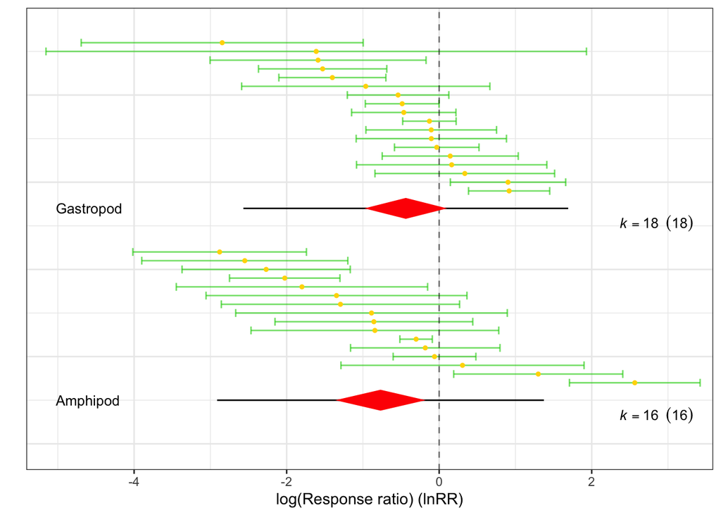

Figure 8— Caterpillars plot of the effects of predation on benthic invertebrate communities compared using the log response ratio

```r
eklof_MR_result <- orchaRd::mod_results(eklof_MR0, mod = "Grazer.type", group = "ExptID")
orchaRd::caterpillars(eklof_MR_result, mod = "Grazer.type", group = "ExptID", xlab = "log(Response ratio) (lnRR)")
```

Like last time, we compare between Fig. 7 and Fig. 8. Again, they both look quite informative.

The last thing we can do is transform these data to percentage. You can also make other transformation depending on what effect size that you are working with, see `?orchard_plot`.

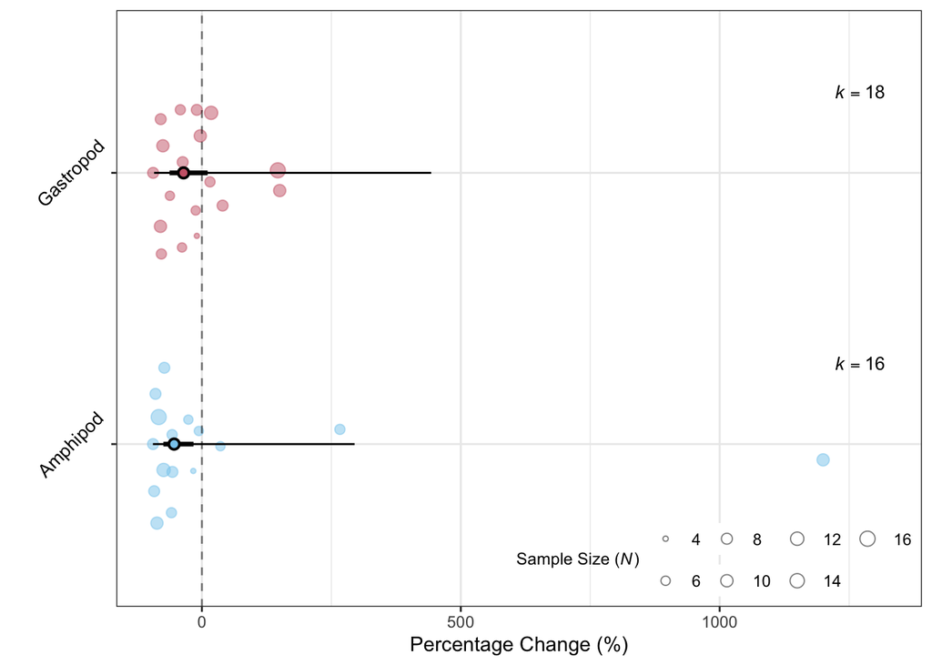

Figure 9— Orchard plots of the effects of predation on benthic invertebrate communities using the percentage difference.

```r
p6_per <- orchaRd::orchard_plot(eklof_MR0, mod = "Grazer.type",  group = "ExptID", xlab = "Percentage Change (%)", angle = 45, N = "N", g = FALSE, transfm = "percentr")

p6_per
```

## 4.3 **Example 3: Maternal-Offspring Morphological Correlations**

Finally, we also look at the case discussed by Lim, Senior, and Nakagawa (2014), who meta-analysed the strength of correlation between maternal and offspring size within-species, across a very wide range of taxa. They found, that typically, there is a moderate positive correlation between maternal size and offspring size within species (i.e. larger mothers have larger offspring). However, they also found evidence for relatively strong phylogenetic effects suggesting that the strength of the association is dependent on evolutionary lineage.

Here we have used an orchard plot to represent the results obtained when meta-analysing the data from Lim, Senior, and Nakagawa (2014) by taxonomic Phylum.

```r
    data(lim)

# Add in the sampling variance
    lim$vi<-(1/sqrt(lim$N - 3))^2

# Lets fit a meta-regression - I will do Article non-independence. The phylogenetic model found phylogenetic effects, however, instead we could fit Phylum as a fixed effect and explore them with an Orchard Plot
  lim_MR<-metafor::rma.mv(yi=yi, V=vi, mods=~Phylum-1, random=list(~1|Article, ~1|Datapoint), data=lim)
  summary(lim_MR)
```

```
Multivariate Meta-Analysis Model (k = 357; method: REML)

  logLik  Deviance       AIC       BIC      AICc
-97.6524  195.3049  213.3049  248.0263  213.8343

Variance Components:

            estim    sqrt  nlvls  fixed     factor
sigma^2.1  0.0411  0.2029    220     no    Article
sigma^2.2  0.0309  0.1757    357     no  Datapoint

Test for Residual Heterogeneity:
QE(df = 350) = 1912.9637, p-val < .0001

Test of Moderators (coefficients 1:7):
QM(df = 7) = 356.6775, p-val < .0001

Model Results:

                       estimate      se     zval    pval    ci.lb   ci.ub
PhylumArthropoda         0.2690  0.0509   5.2829  <.0001   0.1692  0.3687  ***
PhylumChordata           0.3908  0.0224  17.4190  <.0001   0.3468  0.4347  ***
PhylumEchinodermata      0.8582  0.3902   2.1992  0.0279   0.0934  1.6230    *
PhylumMollusca           0.4867  0.1275   3.8175  0.0001   0.2368  0.7366  ***
PhylumNematoda           0.4477  0.3054   1.4658  0.1427  -0.1509  1.0463
PhylumPlatyhelminthes    0.4935  0.2745   1.7980  0.0722  -0.0444  1.0314    .
PhylumRotifera           0.4722  0.3021   1.5634  0.1180  -0.1198  1.0642

---
Signif. codes:  0 '***' 0.001 '**' 0.01 '*' 0.05 '.' 0.1 ' ' 1
```

Noe we can plot a default orchard plot, scaling each effect size by N. Also, because we are using Zr, we can use transfm = “tanh” and it will do the conversions for us:

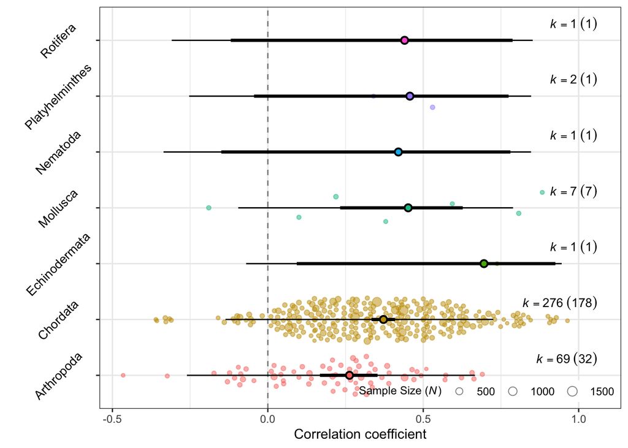

Figure 10— Orchard plot of the the strength of correlation between maternal and offspring size within-species

```r
  #Plot the meta-regression model
  orchaRd::orchard_plot(lim_MR, mod = "Phylum", group = "Article",  xlab = "Correlation coefficient",
    alpha = 0.5, transfm = "tanh", angle = 45, N = "N", cb = FALSE)
```

Now that we have Fig. 10, we can do some small changes to make it pretty and add some more details, such as between study heterogeneity and R<sup>2</sup> for phylum. Currently, the cb argument is “FALSE”, we can change this to “TRUE” to use colour blind friendly colours. Additionally, because we are using `ggplot` we can add element to the figure to make it look pretty.

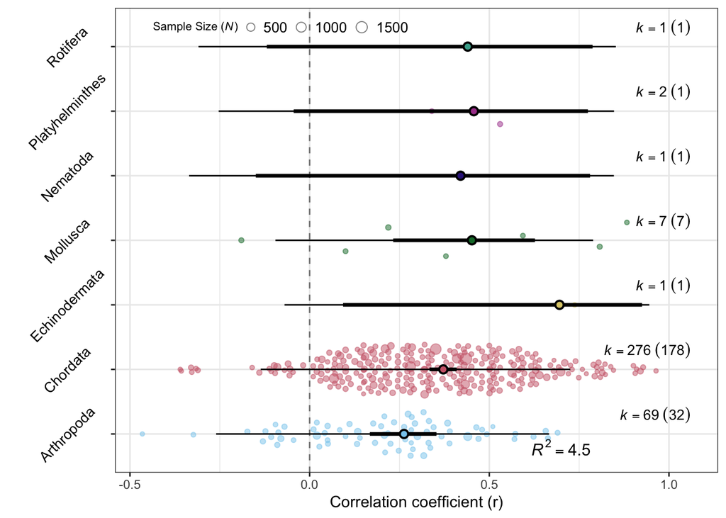

Figure 11— Orchard plot of the the strength of correlation between maternal and offspring size within-species

```r
  # Lets add the R2 on the figure as well as little modifications:
  R2 <- orchaRd::r2_ml(lim_MR)

  # We can draw an orchard plot with R2
  orchaRd::orchard_plot(lim_MR, mod = "Phylum", group = "Article",  xlab = "Correlation coefficient (r)",
                        alpha = 0.5, transfm = "tanh", angle = 45, N = "N", cb = TRUE) +
theme(legend.position= c(0.05, 0.99), legend.justification = c(0,1), legend.key.size = unit(1, "mm")) +
theme(legend.direction="horizontal", legend.title = element_text(size =8),legend.text = element_text(size = 10)) +
annotate(geom="text", x=0.8, y=0.7, label=paste0("italic(R)^{2} == ", round(R2[1],4)*100), color="black", parse = TRUE, size = 4)
```

As in Fig. 11, new elements can be added to the `orchard_plot` to modify it as one sees fit. It will overwrite existing elements. From our orchard plots above, it is clear that the analysis is dominated by data from Chordates and Arthropods, with the other Phyla being much more poorly represented. Second, there is a difference between the strength of a typical correlation within these two well represented groups (the correlation is stronger in Chordates), which arguably would explain the phylogenetic signals detected by Lim, Senior, and Nakagawa (2014). Lastly, although there are differences within the typical correlation between Chordates and Arthropods, there remains a large overlap in predicted range of individual effect sizes; individual species within Phyla are still highly variable.

Finally, we make a comparable caterpillars plot.

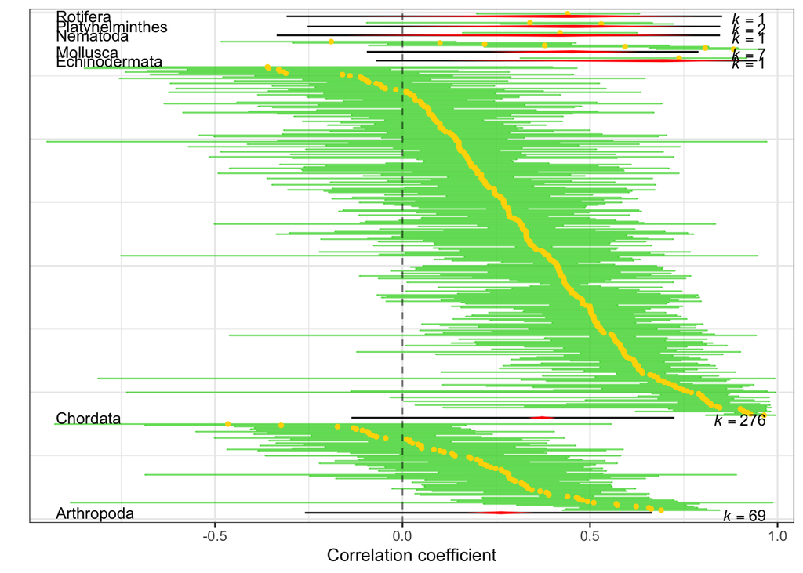

Figure 12— Caterpillars plot of the the strength of correlation between maternal and offspring size within-species

```r
  #Plot the meta-regression model
  lim_MR_results <- orchaRd::mod_results(lim_MR, mod = "Phylum", group = "Article")
  orchaRd::caterpillars(lim_MR_results, mod = "Phylum", group = "Article",  xlab = "Correlation coefficient", transfm = "tanh", g = FALSE)
```

Compared to the orchard plot Fig. 11, Fig. 12 does not look as elegant, unlike the previous comparisons. This is because the groups with small sample sizes are packed at the top of the figure.

From Fig. 11 we can see that many taxonomic groups have very little data. We may want instead to just focus the readers attention to means of groups with sufficient data. The new `mod_results` function allows us to do this using the maginalised means approach. We can do that as follows:

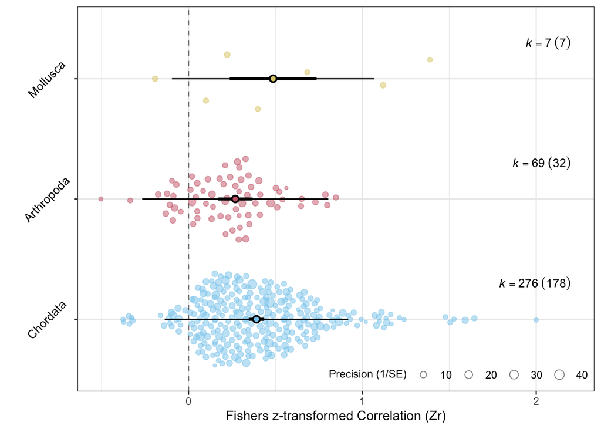

```r
  #Plot the meta-regression model
  lim_MR_results <- orchaRd::mod_results(lim_MR, mod = "Phylum", group = "Article",
                                           at = list(Phylum = c("Chordata", "Arthropoda", "Mollusca")),
                                           subset = TRUE)
  orchaRd::orchard_plot(lim_MR_results, xlab = "Fishers z-transformed Correlation (Zr)",  g = TRUE, angle = 45)
```

We can now see that Fig. 13 limits what it plots to only the three levels relevant for presentation.

**Important**

We have noted a bug at this point in the `orchaRd` package. In updating the `transf` pipeline we’ve now noticed a bug when combining subsetting of levels using the `at` argument and the `subset` argument. This still works, but you cannot currently combine it with any back-transformation of the effect size, which is why we have reverted back to `Zr`. We’re working on fixing this.

We may also at times want to revert back to a normal plot with catagorical variables on the x-axis. We can do this by setting `flip` argument to `FALSE`.

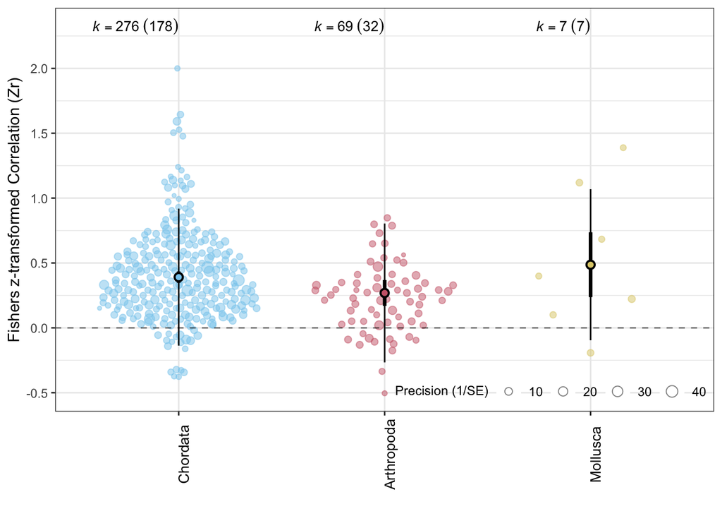

```r
  #Plot the meta-regression model
  lim_MR_results <- orchaRd::mod_results(lim_MR, mod = "Phylum", group = "Article",
                                           at = list(Phylum = c("Chordata", "Arthropoda", "Mollusca")),
                                           subset = TRUE)
  orchaRd::orchard_plot(lim_MR_results, xlab = "Fishers z-transformed Correlation (Zr)", g = TRUE, flip = FALSE)
```

### 4.3.1 Controlling bubble point sizes

When creating small figures (e.g., for multi-panel layouts or journal column widths), the default point sizes can cause bubbles to overlap heavily. The `point.size` argument accepts a numeric vector of length 2 specifying the minimum and maximum bubble size. Points are still scaled by precision (or sample size), but within the specified range (Fig. 15):

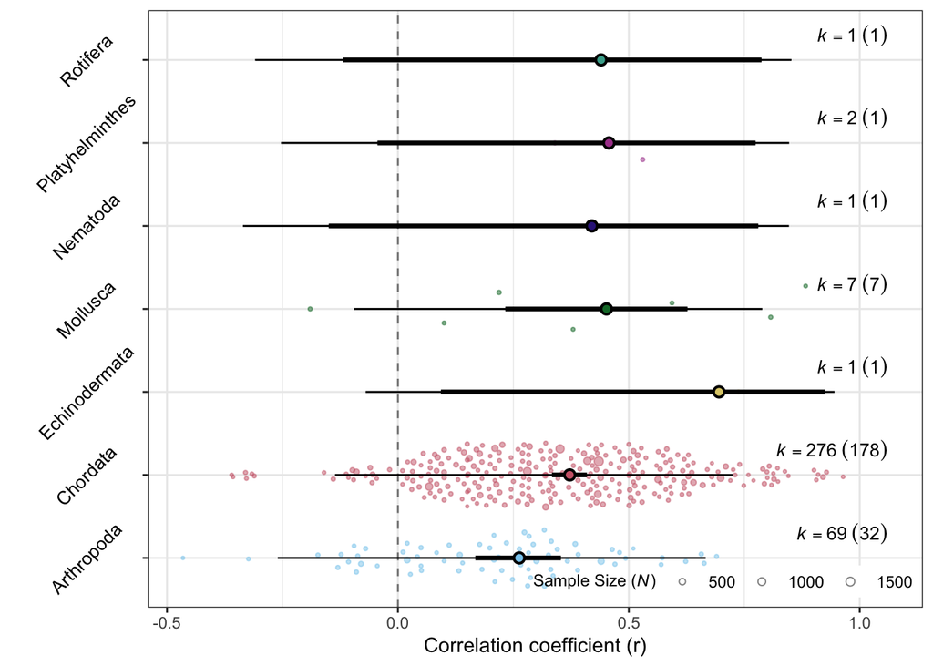

Figure 15— Orchard plot with reduced point sizes, useful for compact figures.

```r
orchaRd::orchard_plot(lim_MR, mod = "Phylum", group = "Article",
  xlab = "Correlation coefficient (r)", transfm = "tanh", N = "N",
  point.size = c(0.5, 2), angle = 45)
```

### 4.3.2 Keeping original category capitalisation and reordering

By default, `orchard_plot()` capitalises the first letter of each moderator level. Set `upper = FALSE` to preserve the original case. This is also compatible with `mod.order`, which lets you reorder categories in the plot. When `upper = FALSE`, pass `mod.order` values in the same case as your data (Fig. 16):

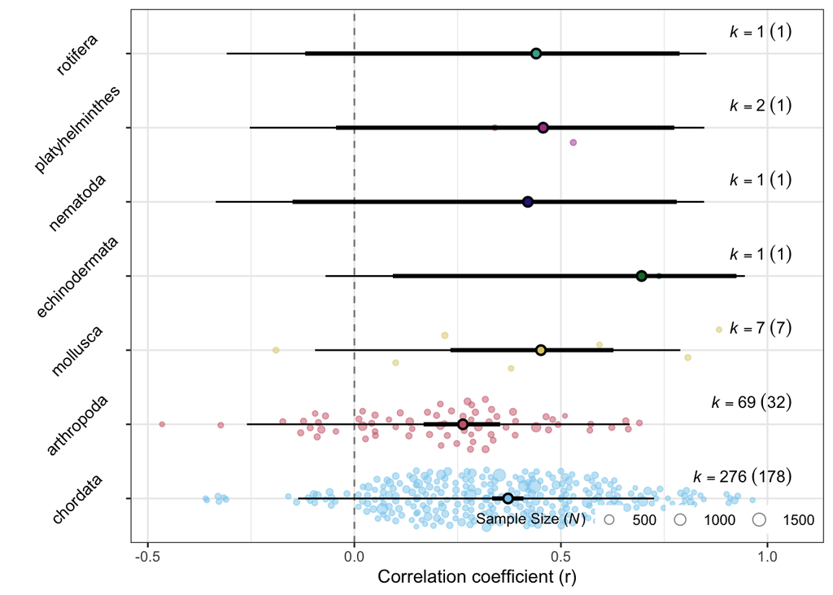

Figure 16— Orchard plot with original lowercase category names in a custom order.

```r
# Lowercase phylum names
lim_lower <- lim
lim_lower$Phylum <- tolower(lim_lower$Phylum)
lim_lower_MR <- metafor::rma.mv(yi = yi, V = vi, mods = ~ Phylum - 1,
  random = list(~1 | Article, ~1 | Datapoint), data = lim_lower)

# Custom order using original lowercase names
my_order <- c("chordata", "arthropoda", "mollusca", "echinodermata",
              "nematoda", "platyhelminthes", "rotifera")

orchaRd::orchard_plot(lim_lower_MR, mod = "Phylum", group = "Article",
  xlab = "Correlation coefficient (r)", transfm = "tanh", N = "N",
  upper = FALSE, mod.order = my_order, angle = 45)
```

### 4.3.3 Adjusting annotation text size

When plots have many moderator levels, the default *k* and *g* labels can feel crowded. The `k.size` argument controls the font size of these annotations. Compare the default (`k.size = 3.5`) with a larger size (Fig. 17):

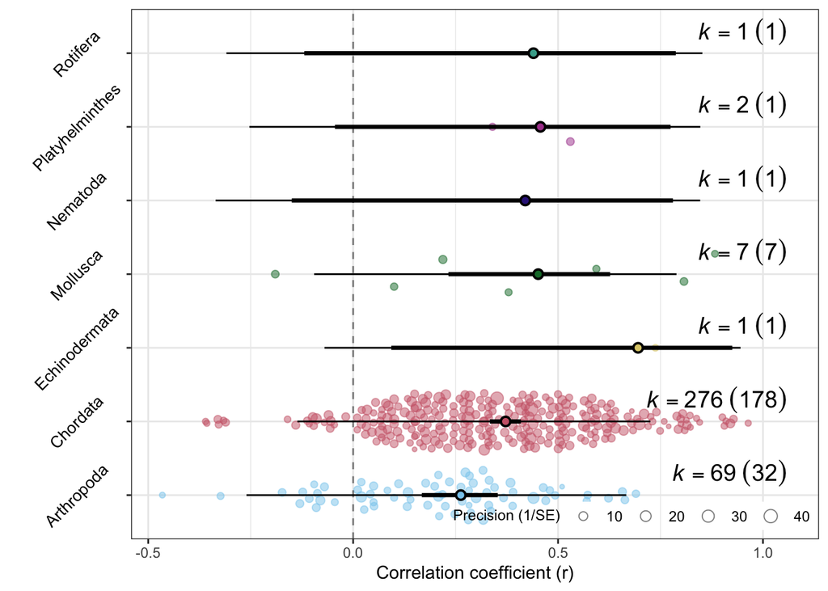

Figure 17— Orchard plot with larger k and g annotations (k.size = 5).

```r
orchaRd::orchard_plot(lim_MR, mod = "Phylum", group = "Article",
  xlab = "Correlation coefficient (r)", transfm = "tanh",
  angle = 45, k.size = 5)
```

### 4.3.4 Displaying point estimates and confidence intervals

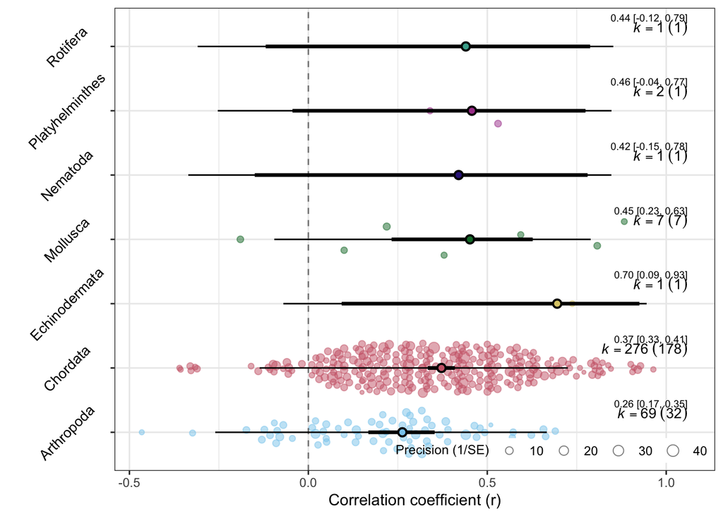

Figure 18— Orchard plot with point estimates and 95% CIs displayed alongside k labels.

```r
orchaRd::orchard_plot(lim_MR, mod = "Phylum", group = "Article",
  xlab = "Correlation coefficient (r)", transfm = "tanh",
  angle = 45, est = TRUE, est.size = 2.5)
```

You can also show estimates without the *k*/*g* labels by setting `k = FALSE`. This can be useful when sample sizes are already reported in accompanying tables (Fig. 19):

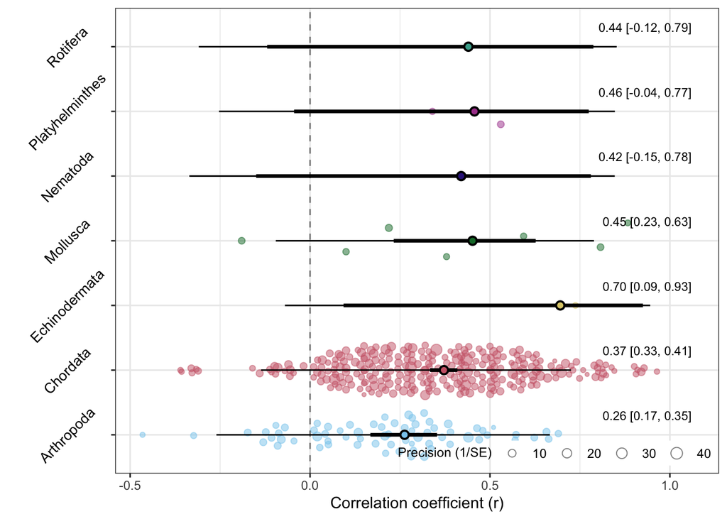

Figure 19— Orchard plot showing only point estimates and CIs (k labels suppressed).

```r
orchaRd::orchard_plot(lim_MR, mod = "Phylum", group = "Article",
  xlab = "Correlation coefficient (r)", transfm = "tanh",
  angle = 45, est = TRUE, k = FALSE, est.size = 3)
```

# 5 **Orchard Plots with Meta-regression Models: Marginalised and conditional means with heteroscedastic residual variances**

In `orchaRd` 2.0 we’ve made some major updates to the types of models that can be used with the package. Meta-analyses in ecology and evolution often fit a multitude of moderators and random effects within a single model. This is even desirable in many cases to deal with high heterogeneity and disentangle the independent contributions of moderators to changes in mean effect size. The challenge with the previous version of the package was that it was difficult to accommodate these models. However, the `emmeans` package is an excellent solution to the problem. It will produce marginsalised or conditional mean estimates for a given level of moderator. This includes models with categorical and continuous moderators.

An additional issue that is of importance with meta-regression models is the need to deal with heteroscedastic variance across levels of a moderator. Homogeneity of variance assumptions are often violated in meta-analysis. `orchaRd` 2.0 allows the user to fit models that explicitly estimate different residual variances reducing the probability of type I errors.

In this section, we show users: 1) how to fit these models using `metafor` and 2) how these models interface with the `orchaRd` package to produce pretty plots that capture the model predictions.

## 5.1 **Example 4: Meta-regression and heterogeneous variance models**

Meta-regression models with single categorical moderators are extremely common. Meta-analyst’s want to estimate the mean effect size within levels of a moderator and test whether these means are significantly different from each other. One inherent assumption to fitting these models is that we are assuming that the within study (or residual) variance within these groups is the same (i.e., “homogeneity of variance assumption”). This assumption will likely be violated in many situations in meta-regression models. Unless one conducts a sub-group analysis for each level of the moderator (although this is less powerful and makes it hard to test whether levels are significantly different) different residual variances need to be explicitly modeled in `metafor`. Fortunately, this can be done. `orchaRd` 2.0 now allows plotting of these models with their corresponding CI’s and PI’s.

We’ll work with a meta-analysis by O’Dea et al. (2019). In this meta-analysis, the authors were interested in testing whether developmental temperature in fish had an effect on mean and variance in a host of phenotypic traits. They used experimental studies manipulating developmental temperatures using the log response ratio (`lnrr`) and the log coefficient of variation (`lncvr`) as their effect sizes. We’ll only focus on `lnrr` here for demonstration purposes. Importantly, they categorised effect sizes as having come from one of 4 trait categories: Behaviour, Life-history, Morphology and Physiology. They were interested in whether developmental temperature impact trait types differently. We’ll first explore how to fit a meta-regression model that explicitly estimates residual variance in each of these trait levels.

First, load the data.

```r
  # Load the dataset that comes with orchaRd
    data(fish)

  # Subset data for demonstration purposes.
    warm_dat <- fish
```

To fit a heterogeneous variance model in `metafor` we need to use some additional arguments and specify the random effect structure differently (i.e., specify inner argument). To do this, we need to add the `struc = HCS` to the argument list, which specifies the variance structure of an ~inner|outer formula of a particular random effect. In this case, we’re assuming a heteroscedastic compound symmetry structure. To avoid estimating the correlation / covariance between levels we need to also add the `rho` argument and set this to 0. This will assume that the covariance between the levels is set to 0 (although it could be estimated).

Once we have these additional arguments we need to modify our random effect structure. Note that `metafor` does not estimate a residual / within study variance. We need to explicitly add an observation level random effect, in this case `es_ID`. If we have more than one effect size / study (which is common) then we want to have this random effect in our models.

```r
model_het <- metafor::rma.mv(    yi = lnrr, V = lnrr_vi,
                               mods = ~ trait.type, method = "REML", test = "t",
                             random = list(~1 | group_ID, ~1 + trait.type| es_ID),
                                rho = 0, struc = "HCS",
                               data = warm_dat,
                            control = list(optimizer="optim", optmethod="Nelder-Mead"))
model_het
```

```
Multivariate Meta-Analysis Model (k = 410; method: REML)

Variance Components:

            estim    sqrt  nlvls  fixed    factor
sigma^2    0.0143  0.1196     84     no  group_ID

outer factor: es_ID      (nlvls = 410)
inner factor: trait.type (nlvls = 4)

            estim    sqrt  k.lvl  fixed         level
tau^2.1    0.2144  0.4630      4     no     behaviour
tau^2.2    0.2121  0.4605      4     no  life-history
tau^2.3    0.0232  0.1522    323     no    morphology
tau^2.4    0.0320  0.1790     79     no    physiology
rho        0.0000                   yes

Test for Residual Heterogeneity:
QE(df = 406) = 39294.5728, p-val < .0001

Test of Moderators (coefficients 2:4):
F(df1 = 3, df2 = 406) = 3.0890, p-val = 0.0271

Model Results:

                        estimate      se     tval   df    pval    ci.lb   ci.ub
intrcpt                   0.1848  0.2713   0.6811  406  0.4962  -0.3485  0.7180
trait.typelife-history    0.5576  0.3701   1.5068  406  0.1326  -0.1699  1.2851
trait.typemorphology     -0.1846  0.2714  -0.6801  406  0.4968  -0.7181  0.3489
trait.typephysiology     -0.1712  0.2730  -0.6272  406  0.5309  -0.7079  0.3655

intrcpt
trait.typelife-history
trait.typemorphology
trait.typephysiology

---
Signif. codes:  0 '***' 0.001 '**' 0.01 '*' 0.05 '.' 0.1 ' ' 1
```

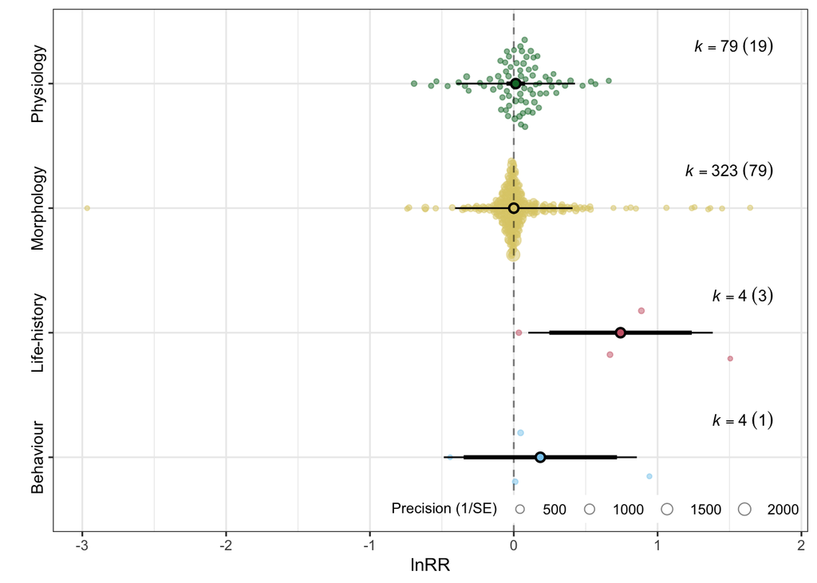

Figure 20— Orchard plot with heteroscedastic error for trait typess

```r
het_model <- orchaRd::mod_results(model_het,
                                     group = "group_ID",
                                       mod = "trait.type")

orchaRd::orchard_plot(het_model, xlab = "lnRR")
```

We can now see from Fig. 20 that the variance in effects for the morphological and physiological trait categories are smaller than for life-history and behavioural trait categories; likely because of the very small sample sizes in the latter trait categories.

As a second example, we can turn to Pottier et al. (2021) who did a meta-analysis comparing acclimation differences between males and females. Pottier et al. (2021) found that aquatic and terrestrial systems differed in their variability of effects. Here, we’ll also show how phylogenetic correlation matrices can be incorporated within the models and work with orchaRd.

```r
# Clear working space
rm(list = ls())

# Load the data
data("pottier")

# Load the phylogenetic correlation matrix
data("phylo_matrix")

# Load the sampling variance matrix
data("VCV_dARR")
```

Now that we have all the data and matrices loaded, we can fit the multi-level mete-regression model.

```r
##### Heteroscedasticity modeled at the effect size level
mod.habitat_het <-  rma.mv(yi=dARR, V=VCV_dARR,mods= ~habitat,method="REML",test="t",dfs="contain",
                           random=list(~1|species_ID,~1|phylogeny,~habitat|es_ID),struct="HCS", rho=0, R =list(phylogeny = phylo_matrix),data=pottier)
mod.habitat_het
```

```
Multivariate Meta-Analysis Model (k = 1089; method: REML)

Variance Components:

            estim    sqrt  nlvls  fixed      factor    R
sigma^2.1  0.0090  0.0948    138     no  species_ID   no
sigma^2.2  0.0129  0.1136    138     no   phylogeny  yes

outer factor: es_ID   (nlvls = 1089)
inner factor: habitat (nlvls = 2)

            estim    sqrt  k.lvl  fixed        level
tau^2.1    0.0716  0.2677    929     no      aquatic
tau^2.2    0.0082  0.0907    160     no  terrestrial
rho        0.0000                   yes

Test for Residual Heterogeneity:
QE(df = 1087) = 56246.7341, p-val < .0001

Test of Moderators (coefficient 2):
F(df1 = 1, df2 = 136) = 9.2383, p-val = 0.0028

Model Results:

                    estimate      se     tval   df    pval    ci.lb    ci.ub
intrcpt               0.2087  0.0655   3.1856  136  0.0018   0.0792   0.3383
habitatterrestrial   -0.1492  0.0491  -3.0394  136  0.0028  -0.2463  -0.0521

intrcpt             **
habitatterrestrial  **

---
Signif. codes:  0 '***' 0.001 '**' 0.01 '*' 0.05 '.' 0.1 ' ' 1
```

Now we can produce an `orchaRd` plot using this model to show the unequal variance in the two habitat types.

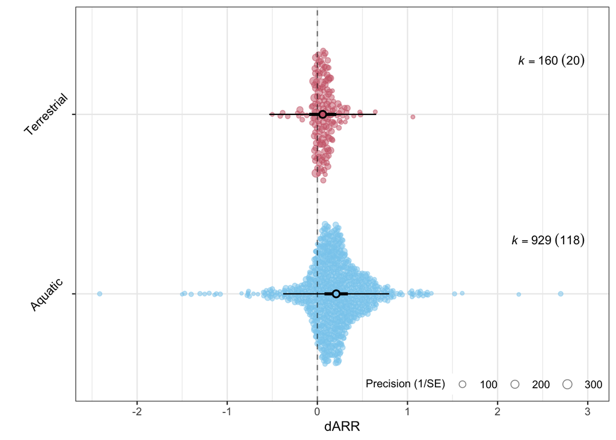

Figure 21— Orchard plot with heteroscedastic error for habitat type

```r
orchard_plot(mod.habitat_het,  group = "species_ID", mod = "habitat", xlab = "dARR", angle = 45)
```

We can also create the model results table (Tab. 1).

```r
flextable::flextable(mod_results(mod.habitat_het,  group = "species_ID", mod = "habitat")$mod_table)
```

Table 1— Model results table for a model with heteroscedastic error for habitat type

| name | estimate | lowerCL | upperCL | lowerPR | upperPR |
| --- | --- | --- | --- | --- | --- |
| Aquatic | 0.21 | 0.079 | 0.34 | -0.38 | 0.80 |
| Terrestrial | 0.06 | -0.091 | 0.21 | -0.53 | 0.65 |

We might also think about heterogeneous variance existing at multiple random effect levels. These models require a lot of data, and need to be carefully thought about, but we `orchard` 2.0 can also handle these models.

```r
##### Heteroscedasticity modeled at the effect size level
mod.habitat_het2 <-  rma.mv(yi=dARR, V=VCV_dARR,mods= ~habitat,method="REML",test="t",dfs="contain",
                           random=list(~habitat|species_ID,~1|phylogeny,~habitat|es_ID),struct="HCS", rho=0, phi = 0, R =list(phylogeny = phylo_matrix),data=pottier)
mod.habitat_het2
```

```
Multivariate Meta-Analysis Model (k = 1089; method: REML)

Variance Components:

            estim    sqrt  nlvls  fixed     factor    R
sigma^2    0.0098  0.0989    138     no  phylogeny  yes

outer factor: species_ID (nlvls = 138)
inner factor: habitat    (nlvls = 2)

            estim    sqrt  k.lvl  fixed        level
tau^2.1    0.0116  0.1077    118     no      aquatic
tau^2.2    0.0022  0.0469     20     no  terrestrial
rho        0.0000                   yes

outer factor: es_ID   (nlvls = 1089)
inner factor: habitat (nlvls = 2)

              estim    sqrt  k.lvl  fixed        level
gamma^2.1    0.0715  0.2673    929     no      aquatic
gamma^2.2    0.0084  0.0918    160     no  terrestrial
phi          0.0000                   yes

Test for Residual Heterogeneity:
QE(df = 1087) = 56246.7341, p-val < .0001

Test of Moderators (coefficient 2):
F(df1 = 1, df2 = 136) = 14.6883, p-val = 0.0002

Model Results:

                    estimate      se     tval   df    pval    ci.lb    ci.ub
intrcpt               0.2098  0.0581   3.6096  136  0.0004   0.0949   0.3247
habitatterrestrial   -0.1606  0.0419  -3.8325  136  0.0002  -0.2434  -0.0777

intrcpt             ***
habitatterrestrial  ***

---
Signif. codes:  0 '***' 0.001 '**' 0.01 '*' 0.05 '.' 0.1 ' ' 1
```

Again, we can plot this new model normally.

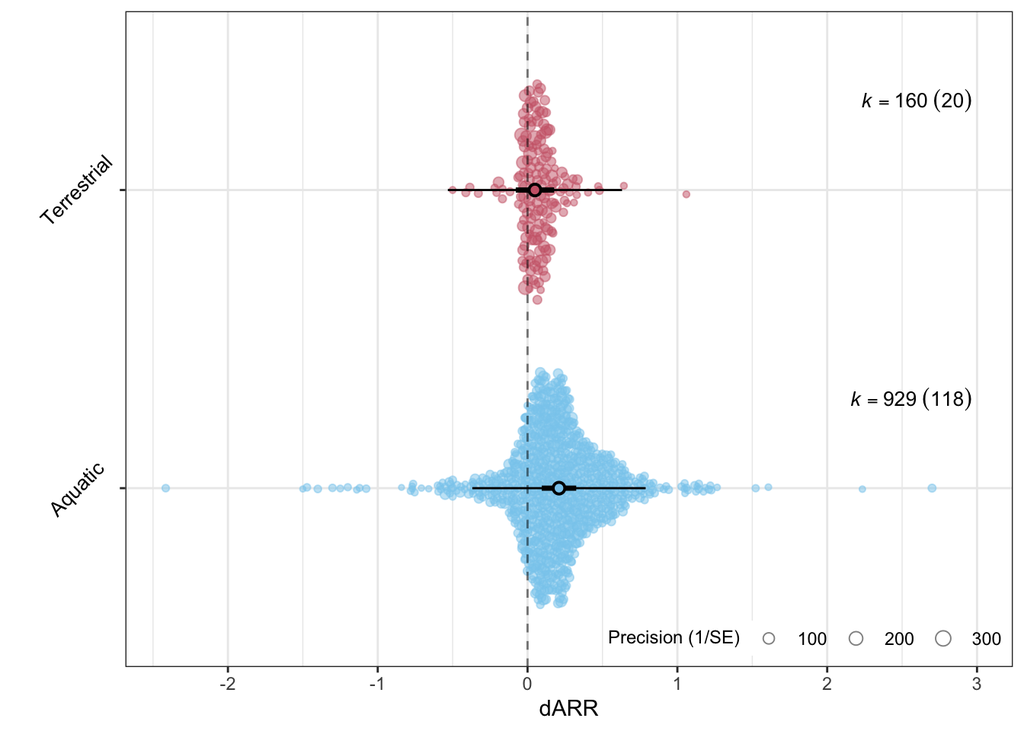

Figure 22— Orchard plot with heteroscedastic error for habitat type at the residual and species level

```r
orchard_plot(mod.habitat_het2, group = "species_ID", mod = "habitat", xlab = "dARR", angle = 45)
```

We can also view the model results table (Tab. 2)

```r
flextable::flextable(mod_results(mod.habitat_het2, group = "species_ID", mod = "habitat")$mod_table)
```

Table 2— Model results table for a model with heteroscedastic error for habitat type at the residual and species level

| name | estimate | lowerCL | upperCL | lowerPR | upperPR |
| --- | --- | --- | --- | --- | --- |
| Aquatic | 0.210 | 0.095 | 0.32 | -0.37 | 0.79 |
| Terrestrial | 0.049 | -0.079 | 0.18 | -0.53 | 0.63 |

## 5.2 **Example 5: Bubble plots with continuous moderators**

`orchaRd` 2.0 can now also create bubble plots. Bubble plots are extremely useful when one has a continuous moderator variable. For example, this might be publication year or sampling variance if one is testing for various forms of publication bias. We’ll demonstrate using two examples.

First, we’ll return to the Lim, Senior, and Nakagawa (2014) dataset. Here, we can fit a model that assessing time-lag effects for studies on captive and wild populations. Say, for the sake of argument, that we expect the time-lag effect to vary by lab/wild conditions. We can fit an interaction model and create bubble plots for these situations (Fig. 23):

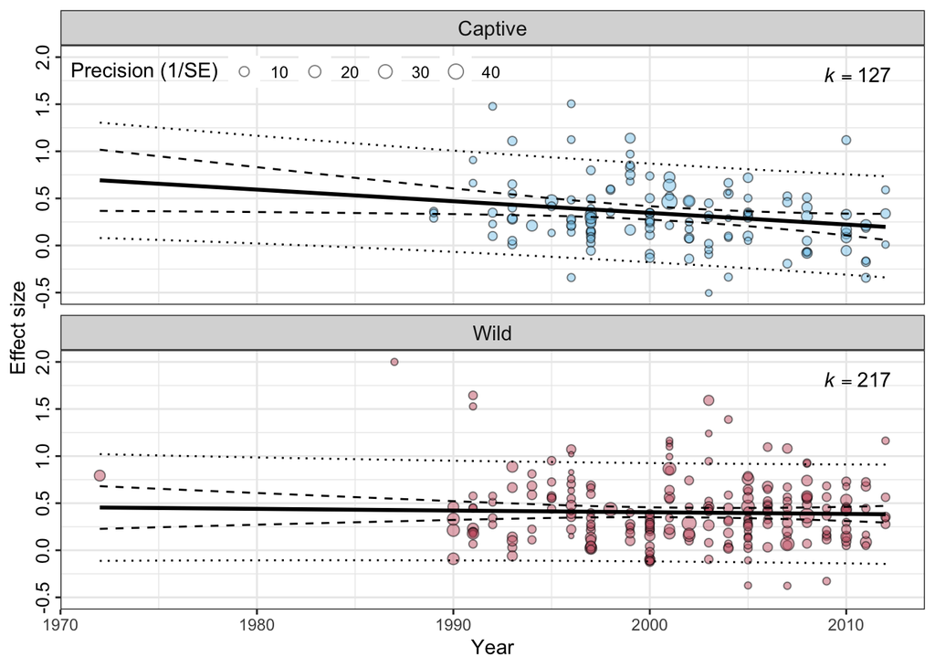

Figure 23— Bubble plot with Lim, Senior, and Nakagawa (2014) dataset assessing publication bias (time-lag bias) in wild and captive studies.

```r
data(lim)
lim[, "year"] <- as.numeric(lim$year)
lim$vi<- 1/(lim$N - 3)
model<-metafor::rma.mv(yi=yi, V=vi, mods= ~Environment*year,
                       random=list(~1|Article,~1|Datapoint), data=na.omit(lim))


lim_bubble <- orchaRd::mod_results(model, mod = "year", group = "Article",
                    weights = "prop", by = "Environment")

orchaRd::bubble_plot(lim_bubble, group = "Article",  mod = "year", xlab = "Year", legend.pos = "top.left")
```

The `point.size` argument also works with `bubble_plot()`. Here we reduce the bubble sizes to `c(0.5, 2)` for a more compact presentation (Fig. 24):

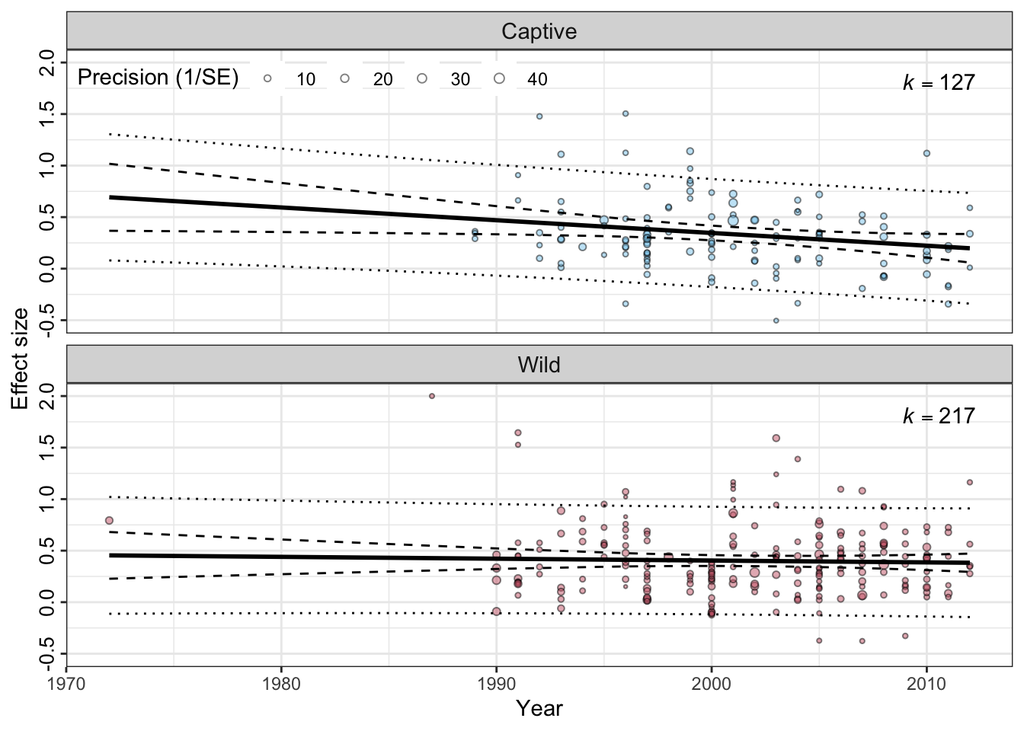

Figure 24— Bubble plot with reduced point sizes for compact figures.

```r
orchaRd::bubble_plot(lim_bubble, group = "Article", mod = "year",
  xlab = "Year", legend.pos = "top.left", point.size = c(0.5, 2))
```

### 5.2.1 Bubble plots from raw data (no model)

Sometimes you may want to create a quick exploratory bubble plot directly from a raw `data.frame`, without fitting a meta-analytic model first. Since `orchaRd` 2.0, `bubble_plot()` accepts a `data.frame` as input. When you do this, the function plots the raw effect sizes against the moderator — no fitted regression line, confidence interval, or prediction interval is drawn. You simply need to tell `bubble_plot()` which columns contain the effect sizes (`yi`), sampling variances (`vi`), study identifier (`stdy`), and the continuous moderator (`mod`). You can also pass a `by` argument to facet by a categorical variable (Fig. 25).

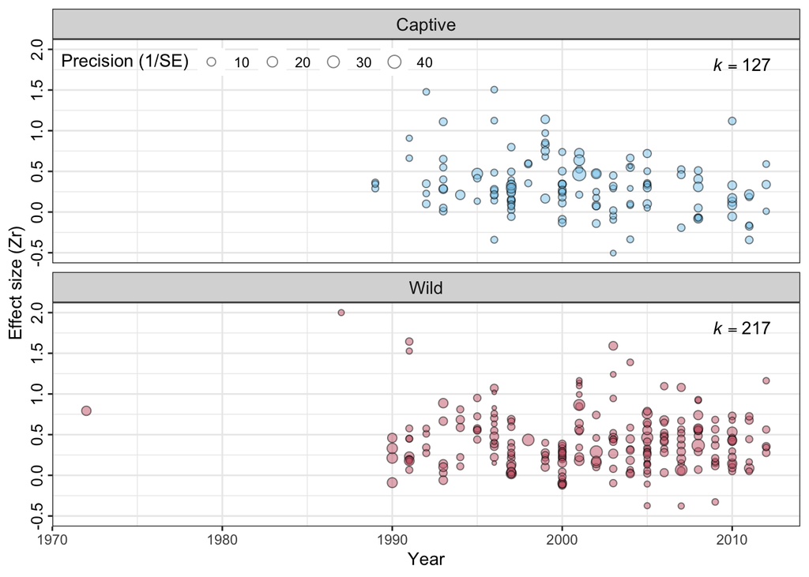

Figure 25— Raw data bubble plot using the Lim, Senior, and Nakagawa (2014) dataset, without any model fit. Points are sized by precision (1/SE) and faceted by environment type.

```r
lim_raw <- na.omit(lim)
orchaRd::bubble_plot(
  object = lim_raw,
  yi    = "yi",
  vi    = "vi",
  stdy  = "Article",
  mod   = "year",
  group = "Article",
  by    = "Environment",
  xlab  = "Year",
  ylab  = "Effect size (Zr)",
  legend.pos = "top.left"
)
```

This can be useful for initial data exploration, checking for outliers, or when you want to visualise the raw data alongside a separate model-based plot for comparison.

As second example, we’ll return back to Pottier et al. (2021), who collected data on body mass for species in the data set where the acclimation response ratio (ARR) was calculated. We might expect the ARR to vary by body mass because small species might be able to acclimate faster than larger species. Using a simplified version of Pottier et al. (2021)’s model, we can look at this effect (Fig. 26):

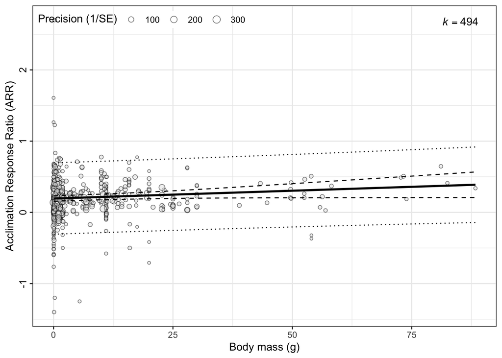

Figure 26— Bubble plot with Pottier et al. (2021) dataset assessing whether body mass affects the acclimation response ratio (ARR).

```r
  # extract complete cases
      data(pottier)
      pottier2 <- pottier[complete.cases(pottier$body_mass),]

  # Model body mass effects
mod.body_mass <-  metafor::rma.mv(yi = dARR, V = Var_dARR,mods= ~body_mass, method="REML", test="t", dfs="contain",
                           random=list(~1|species_ID, ~1|es_ID), data = pottier2)

orchaRd::bubble_plot(mod.body_mass, mod = "body_mass", group = "species_ID", xlab = "Body mass (g)", ylab = "Acclimation Response Ratio (ARR)", legend.pos = "top.left")
```

We may want to colour code the points based on some grouping variable, such as habitat. As indicated through the vignette, we can override layers of the orchard plot to do this fairly easily (Fig. 27).

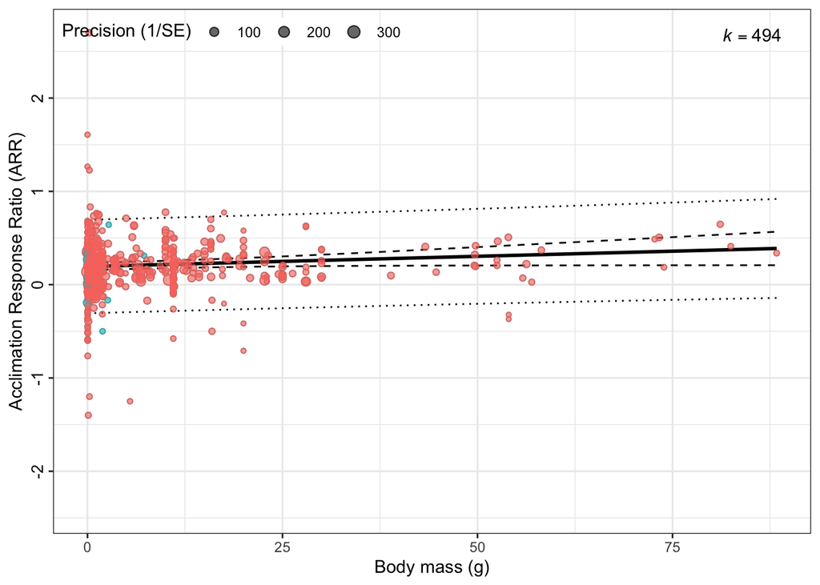

Figure 27— Bubble plot with Pottier et al. (2021) dataset assessing whether body mass affects the acclimation response ratio (ARR), with points coloured by habitat type. ‘Blue’ are terrestrial species, ‘red’ are aquatic species.

```r
orchaRd::bubble_plot(mod.body_mass, mod = "body_mass", group = "species_ID", xlab = "Body mass (g)", ylab = "Acclimation Response Ratio (ARR)", legend.pos = "top.left") + geom_point(data = pottier, aes(x = body_mass, y = dARR, color = habitat, size = 1/sqrt(Var_dARR)), alpha = 0.6) + scale_color_discrete()
```

## 5.3 **Example 6: Meta-regression and conditional mean effect sizes**

We’ll now demonstrate how multi-moderator meta-regression models can be used with `orchaRd` 2.0, by plotting conditional mean effects within categories of a single moderator.

To demonstrate how to do this we’ll again turn to O’Dea et al. (2019) as our example data set. We’ll first load the data set, if you haven’t already done so:

```r
  # Load the dataset that comes with orchaRd
    data(fish)

  # Subset data for demonstration purposes.
    warm_dat <- fish
```

Now that we have the data set assume we are interested in modelling multiple moderators that we hypothesize will explain effect size variance. We want to provide a model that will allow us to understand the effects of each multiple moderators on mean effect size. We know that `experimental_design` and the temperature difference between treatments (`deg_diff`) are expected to impact mean effect size. We also expect experiments that last longer to have stronger effects (`treat_end_days`). We’ll now extend our model from Section 5.1 above to include these moderators so we can look at the effects of each controlling for each other.

```r
 # Fit the metaregerssion model
model <- metafor::rma.mv(yi = lnrr, V = lnrr_vi,
                         mods = ~ experimental_design + trait.type + deg_dif + treat_end_days,
                         method = "REML", test = "t",
                         random = list(~1 | group_ID, ~1 + trait.type| es_ID),
                                rho = 0, struc = "HCS",
                         data = warm_dat,
                         control=list(optimizer="optim", optmethod="Nelder-Mead"))

model
```

```
Multivariate Meta-Analysis Model (k = 410; method: REML)

Variance Components:

            estim    sqrt  nlvls  fixed    factor
sigma^2    0.0143  0.1196     84     no  group_ID

outer factor: es_ID      (nlvls = 410)
inner factor: trait.type (nlvls = 4)

            estim    sqrt  k.lvl  fixed         level
tau^2.1    0.2145  0.4631      4     no     behaviour
tau^2.2    0.2147  0.4634      4     no  life-history
tau^2.3    0.0226  0.1503    323     no    morphology
tau^2.4    0.0320  0.1790     79     no    physiology
rho        0.0000                   yes

Test for Residual Heterogeneity:
QE(df = 402) = 38537.0410, p-val < .0001

Test of Moderators (coefficients 2:8):
F(df1 = 7, df2 = 402) = 2.4871, p-val = 0.0165

Model Results:

                                          estimate      se     tval   df
intrcpt                                     0.1637  0.2726   0.6003  402
experimental_designsplit pooled families    0.0339  0.0503   0.6728  402
experimental_designsplit single family      0.0654  0.0687   0.9513  402
trait.typelife-history                      0.5532  0.3721   1.4870  402
trait.typemorphology                       -0.1847  0.2726  -0.6775  402
trait.typephysiology                       -0.1689  0.2745  -0.6153  402
deg_dif                                    -0.0091  0.0051  -1.7891  402
treat_end_days                              0.0007  0.0003   2.2183  402
                                            pval    ci.lb   ci.ub
intrcpt                                   0.5486  -0.3723  0.6997
experimental_designsplit pooled families  0.5015  -0.0651  0.1328
experimental_designsplit single family    0.3420  -0.0697  0.2005
trait.typelife-history                    0.1378  -0.1782  1.2847
trait.typemorphology                      0.4985  -0.7206  0.3512
trait.typephysiology                      0.5387  -0.7085  0.3707
deg_dif                                   0.0744  -0.0190  0.0009  .
treat_end_days                            0.0271   0.0001  0.0014  *

---
Signif. codes:  0 '***' 0.001 '**' 0.01 '*' 0.05 '.' 0.1 ' ' 1
```

Our model is complicated. It not only estimates the effects of trait type, but type of experimental design, degree difference and treatment duration. But, effects of moderators are now conditional on each other. What happens if we just want to plot mean effects for trait type, but we want to condition these effects on a given temperature different? We can do this using calculating conditional meta-analytic means. We can see that there’s not much going on for experimental design, so we will marginalize the means across each level of this moderator. Degree difference is continuous. To deal with continuous moderators we need to specify the levels we want predictions to be made.

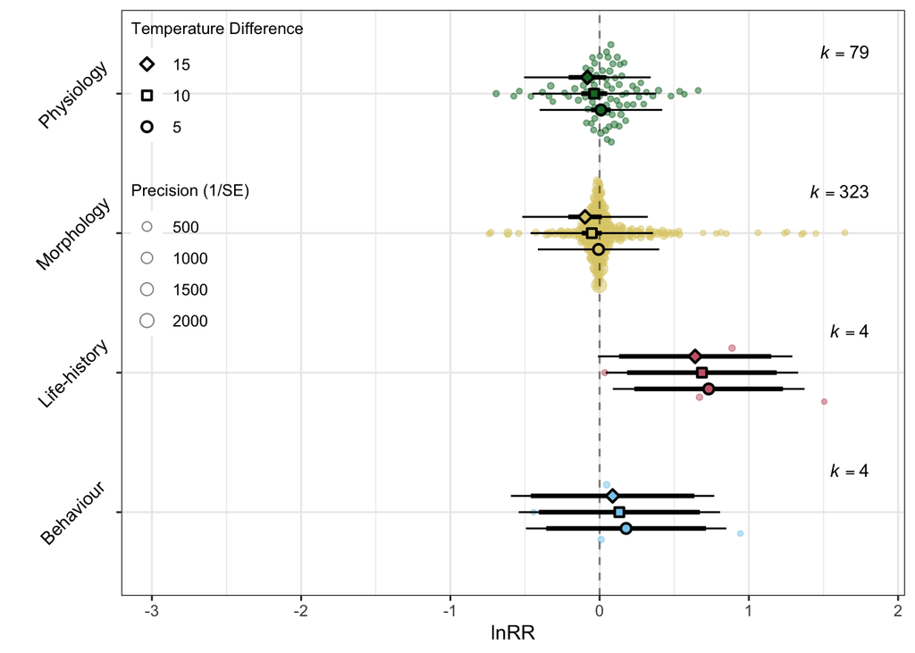

Figure 28— Orchard plot of meta-anlaytic mean estimates conditioned on a 5, 10, and 15 degree Celcius temperture difference

```r
HetModel <- orchaRd::mod_results(model, group = "group_ID", mod = "trait.type", at = list(deg_dif = c(5, 10, 15)), by = "deg_dif", weights = "prop" )

orchaRd::orchard_plot(HetModel, xlab = "lnRR" , angle = 45, g = FALSE, legend.pos = "top.left", condition.lab = "Temperature Difference") +
  theme(legend.direction = "vertical")
```

We can see the orchard plot changes. Here we have a ‘condition’ label, which we have renamed to “Temperature Difference” using the `condition.lab` argument. This new legend specifies the degree difference for each mean predicted. Note that these means effectively average over all levels of experimental design **and** all possible values of `treat_end_days` (i.e., marginalize). We have also made some small changes to the plot. First, we set `g = FALSE` which will suppress the total groups on the plot (e.g. studies), moved the position of legends and angled the labels.

We can also specify the specific value of `treat_end_day`, further conditioning our mean estimates. We can do that as follows:

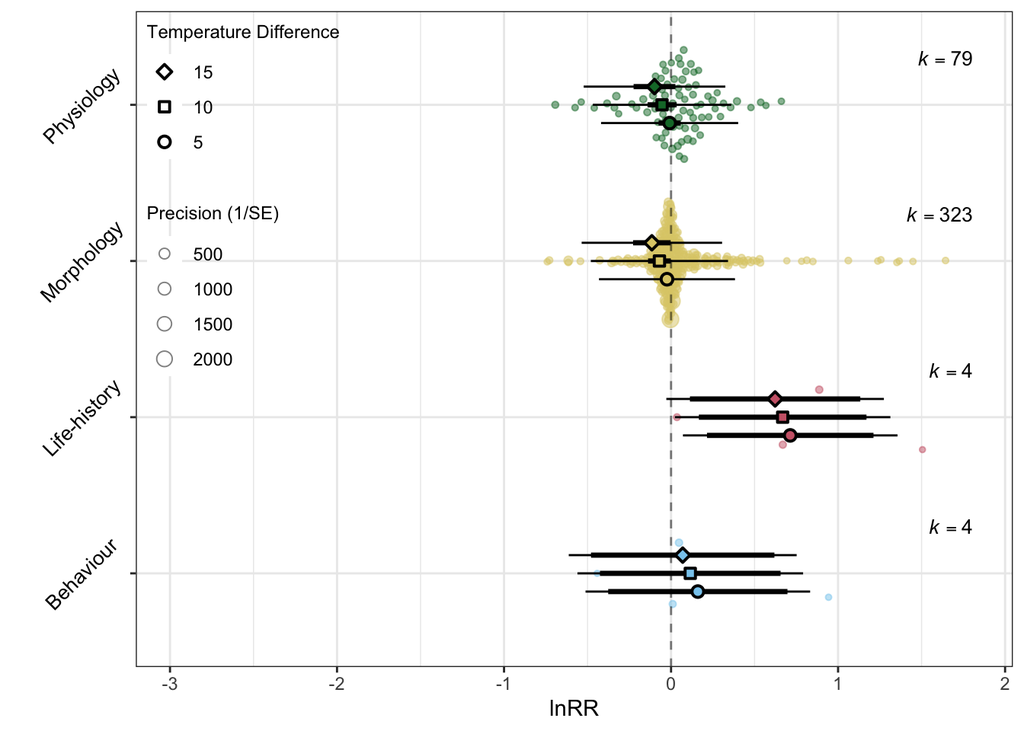

Figure 29— Orchard plot of meta-anlaytic mean estimates conditioned on a 5, 10, and 15 degree Celcius temperture difference

```r
HetModel2 <- orchaRd::mod_results(model, group = "group_ID", mod = "trait.type", at = list(deg_dif = c(5, 10, 15), treat_end_days = c(10)), by = "deg_dif", weights = "prop")

orchaRd::orchard_plot(HetModel2, xlab = "lnRR", angle = 45, g = FALSE, legend.pos = "top.left", condition.lab = "Temperature Difference") +
  theme(legend.direction = "vertical")
```

Now the orchard plot depicts the mean effect sizes (plus 95% CI and PI) for each trait category, at 5, 10 and 15 $^{\circ}$C when the treatment duration is 10 days.

# 6 *New* Leave-on-out Analysis and Plots

One way to assess the robustness of a meta-analytic model is by re-running the model without one or more effect sizes and then comparing the results. A common approach is to re-run the model multiple times, each time removing the effect sizes from a different study. This allows you to see how the overall effect estimate changes when each study is excluded.

This is a leave-one-out analysis Shinichi Nakagawa et al. (2023). It leaves out one study at a time, but you can leave out any group you think can have a large influence on the overall effect estimate. In ecology and evolution meta-analyses, it can be useful to check how the model changes when certain species are left out.

Thanks to [Facundo Decunta](https://github.com/fdecunta), there are now two functions for this: `leave_one_out()` and `orchard_leave1out()`. The first one is to run the analysis, and the second one is to plot the results.

## 6.1 **Example 7: Simple leave-one-out**

Using the data from English and Uller (2016), here is how to run a leave-one-out and plot the results.

First, calculate the effect sizes and fit the model.

```r
data(english)

# Create a new column with 'Author, year' format
english$author_year <- paste(english$Author, english$Year)


# We need to calculate the effect sizes, in this case d
english <- escalc(measure = "SMD",
                  n1i = NStartControl,
                  sd1i = SD_C,
                  m1i = MeanC,
                  n2i = NStartExpt,
                  sd2i = SD_E,
                  m2i = MeanE,
                  var.names = c("SMD", "vSMD"),
                  data = english)

english_MA <- rma.mv(yi = SMD,
                     V = vSMD,
                     random = list(~1 | StudyNo,
                                   ~1 | EffectID),
                    data = english)
```

`leave_one_out()` will re-run the model without one study at a time. The `group` argument is used to specify the grouping variable. In this case, we use the `author_year` variable:

```r
loo_test <- leave_one_out(english_MA, group = "author_year")
loo_test
```

```
                 name estimate lowerCL upperCL lowerPR upperPR
1        Barrett 2009   0.0368  -0.108    0.18   -0.65    0.72
2         Cheney 1983   0.0731  -0.074    0.22   -0.67    0.82
3  Langley-Evans 2006   0.0655  -0.085    0.22   -0.70    0.83
4          Lynch 1983   0.0510  -0.097    0.20   -0.70    0.81
5   Partadiredja 2010   0.0562  -0.091    0.20   -0.69    0.81
6          Sayer 2001   0.0451  -0.100    0.19   -0.70    0.79
7            Sun 2009   0.0736  -0.072    0.22   -0.67    0.81
8             Tu 2003   0.0558  -0.093    0.20   -0.70    0.81
9     Zajistchek 2009   0.0677  -0.083    0.22   -0.69    0.83
10        Mestre 2012   0.0058  -0.110    0.12   -0.61    0.62
11 Saasatamoinen 2013   0.0450  -0.110    0.20   -0.75    0.84
12 Saasatamoinen 2010   0.0664  -0.085    0.22   -0.70    0.83
13        Ozanne 2004   0.0554  -0.100    0.21   -0.66    0.77
14         Zwaan 1991   0.0603  -0.091    0.21   -0.72    0.84
15         Boggs 2005   0.0405  -0.101    0.18   -0.69    0.77
16           May 2015   0.0796  -0.060    0.22   -0.65    0.81
17      Dmitriew 2009   0.0668  -0.083    0.22   -0.70    0.83
18     Heidinger 2012   0.0678  -0.080    0.22   -0.68    0.82
19       Houslay 2015   0.0639  -0.087    0.21   -0.70    0.83
20         Kelly 2014   0.0739  -0.074    0.22   -0.67    0.82
```

We can plot the results with `orchard_leave1out()`. This function takes the output of `leave_one_out()` and creates an orchard plot. The y-axis shows which study was left out.

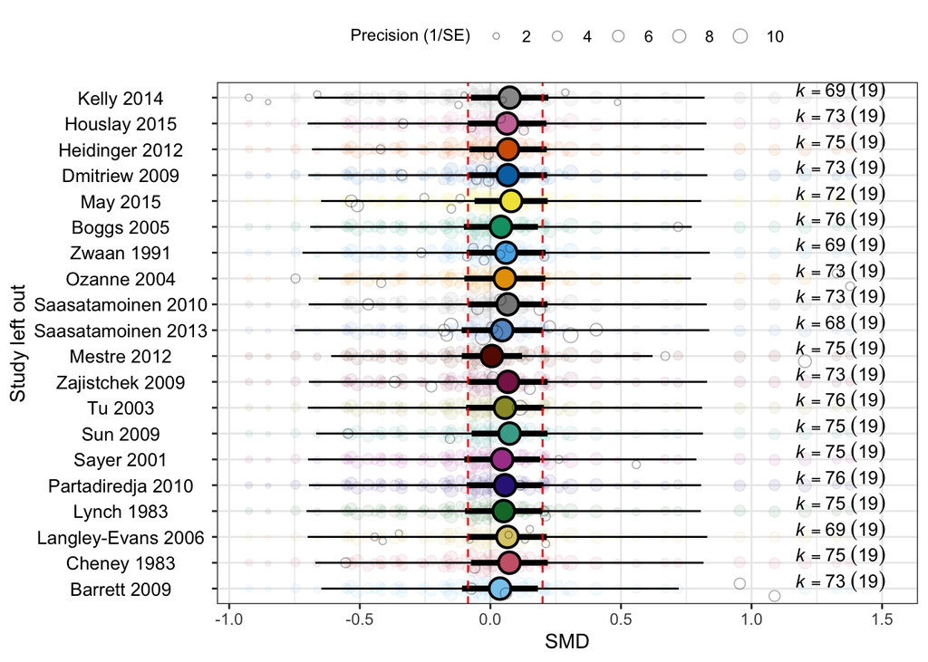

Figure 30— Leave-one-out analysis of the meta-analysis of English and Uller (2016). The y-axis shows which study was left out, and the x-axis shows the effect size (SMD) for each model.

```r
orchard_leave1out(leave1out = loo_test,
                  xlab = "SMD",
                  ylab = "Study left out",
                  trunk.size = 1.2,
                  branch.size = 1.5,
                  alpha = 0.08,
                  legend.pos = "top.out")
```

The dashed red lines show the 95% confidence interval for the overall effect size in the original model. You can removed them by setting `ci_lines = FALSE`. To change the color, use `ci_lines_color = "blue"`, or whatever color you want.

The empty points, called ‘ghost points’, show the effect sizes left-out of that model. You can removed them by setting `ghost_points = FALSE`.

The rest of the arguments are the same as in `orchard_plot()`.